# Analyzing Individual BGG Users

Phil Henrickson

2022-01-02

# **Eglafang’s** BoardGameGeek Collection

This notebook contains a set of analyses for the selected user’s boardgamegeek collection. The bulk of the analysis is focused on building a user-specific predictive model to predict the games that Eglafang is likely to own. This enables to ask questions like, based on the games the user currently owns, what games are a good fit for their collection? What upcoming games are they likely to purchase?

This analysis is based on data from BoardGameGeek that was last updated on **2021-12-20.**

# 1 Collection Overview

We can look at a basic description of the number of games that the user owns, has rated, has previously owned, etc.

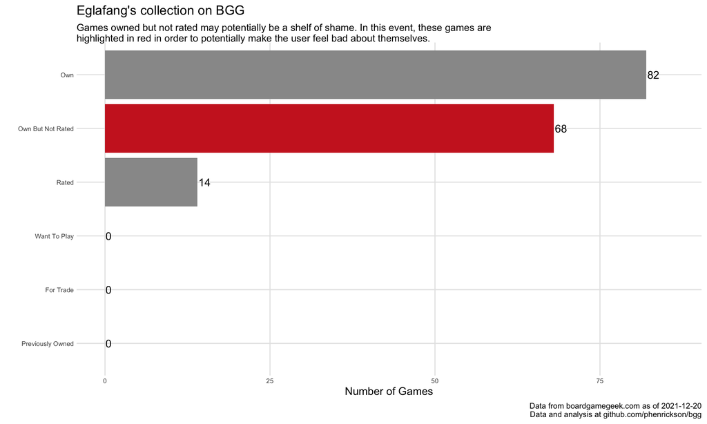

What years has the user owned/rated games from? While we can’t see when a user added or removed a game from their collection, we can look at their collection by the years in which their games were published.

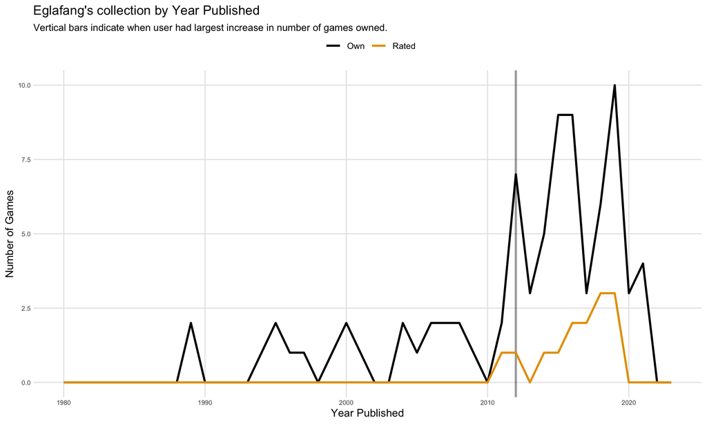

## 1.1 What types of games does Eglafang own?

We can look at the most frequent types of categories, mechanics, designers, and artists that appear in a user’s collection.

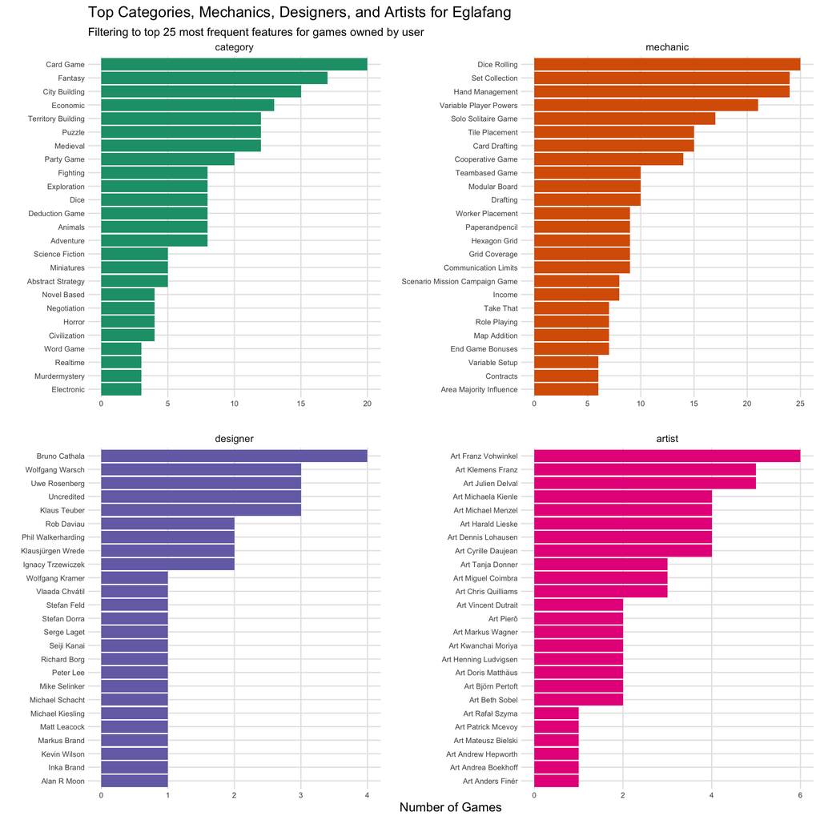

# 2 Modeling **Eglafang’s** Collection

| username | dataset | period | games_owned | games_rated | games_played |
| --- | --- | --- | --- | --- | --- |
| Eglafang | training | published before 2020 | 74 | 14 | 74 |
| Eglafang | test | published 2020 or later | 7 | 0 | 7 |

There are two main (binary) outcomes we will be modeling for the user.

The first, **own** refers to whether the user currently lists a game as owned in their collection. The second, **played** refers to whether the user currently owns, has rated, or previously owned a game. This means the latter will generally have a larger list of games, but may still be a useful category to examine for people who play lots of games without necessarily owning them.

We will train predictive models to learn the probability that the user will own or play individual games based on their features.

## 2.1 Coefficients for Eglafang

We can examine coefficients from the trained modes, which are penalized logistic regressions fit to our two main outcomes. Positive values indicate that a feature increases a user’s probabilility of owning/rating a game, while negative values indicate a feature decreases the probability.

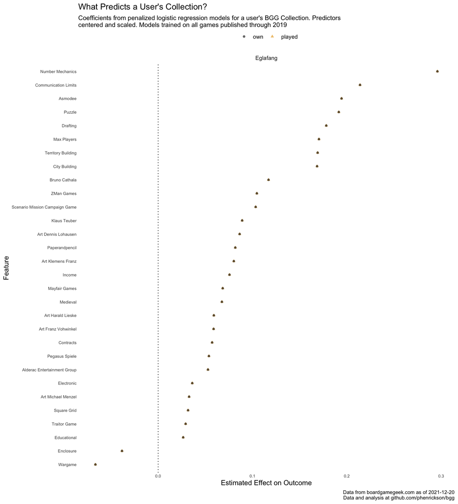

## 2.2 Visualizing Predictors for Eglafang’s Collection

Why did the model identify these features? We can make density plots of the important features for predicting whether the user owned a game. Blue indicates the density for games owned by the user, while grey indicates the density for games not owned by the user.

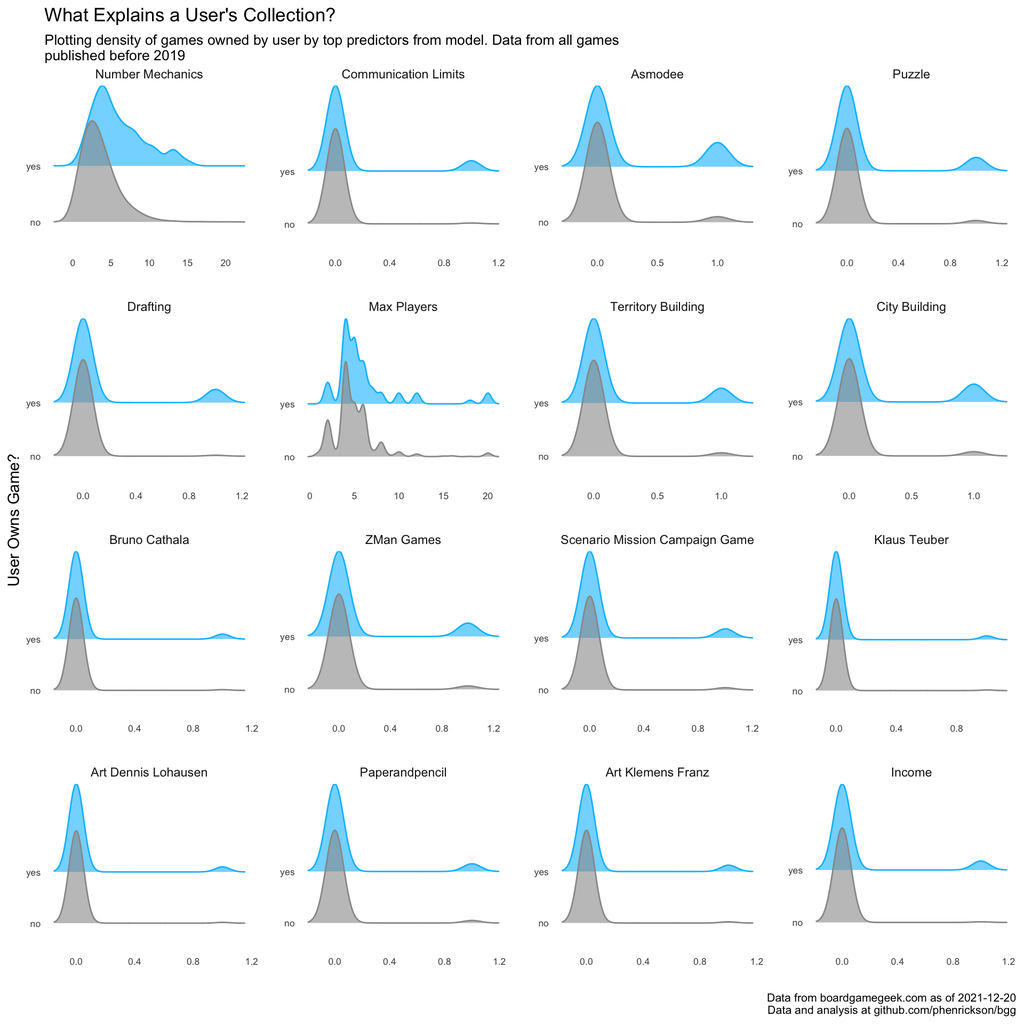

Binary predictors can be difficult to see with this visualization, so we can also directly examine the percentage of games in a user’s collection with a predictor vs the percentage of all games with that predictor.

| username | Feature | % of Games with Feature In_Collection | % of Games with Feature All_Games | Ratio |
| --- | --- | --- | --- | --- |
| Eglafang | Income | 9.5% | 0.7% | 14.5 |
| Eglafang | Drafting | 13.5% | 0.9% | 14.4 |
| Eglafang | Communication Limits | 10.8% | 0.9% | 11.9 |
| Eglafang | End Game Bonuses | 9.5% | 1.2% | 7.7 |
| Eglafang | Contracts | 6.8% | 1.0% | 6.8 |
| Eglafang | Traitor Game | 4.1% | 0.7% | 6.2 |
| Eglafang | Hidden Roles | 4.1% | 0.7% | 5.7 |
| Eglafang | Square Grid | 6.8% | 1.4% | 4.9 |
| Eglafang | Asmodee | 23.0% | 5.2% | 4.4 |
| Eglafang | Territory Building | 14.9% | 3.5% | 4.2 |
| Eglafang | City Building | 17.6% | 4.2% | 4.2 |
| Eglafang | Puzzle | 13.5% | 3.3% | 4.1 |
| Eglafang | Scenario Mission Campaign Game | 9.5% | 2.3% | 4.1 |
| Eglafang | Mayfair Games | 9.5% | 2.3% | 4.0 |
| Eglafang | ZMan Games | 13.5% | 3.5% | 3.9 |
| Eglafang | Paperandpencil | 8.1% | 2.6% | 3.1 |
| Eglafang | Electronic | 2.7% | 0.9% | 3.1 |
| Eglafang | Pegasus Spiele | 13.5% | 4.7% | 2.9 |
| Eglafang | Medieval | 16.2% | 6.2% | 2.6 |
| Eglafang | Alderac Entertainment Group | 4.1% | 1.5% | 2.6 |
| Eglafang | Educational | 4.1% | 1.6% | 2.6 |
| Eglafang | Role Playing | 8.1% | 3.2% | 2.5 |
| Eglafang | Set Collection | 31.1% | 17.5% | 1.8 |
| Eglafang | Wargame | 1.4% | 12.5% | 0.1 |
| Eglafang | Enclosure | 0.0% | 1.3% | 0.0 |

# 3 Assess Model’s Performance on Training Set

Before predicting games in upcoming years, we can examine how well the model did and what games it liked in the training set. In this case, we used resampling techniques (cross validation) to ensure that the model had not seen a game before making its predictions.

## 3.1 Separation Plot

An easy way to examine the performance of classification model is to view a separation plot. We plot the predicted probabilities from the model for every game (from resampling) from lowest to highest. We then overlay a blue line for any game that the user does own. A good classifier is one that is able to *separate* the blue (games owned by the user) from the white (games not owned by the user), with most of the blue occurring at the highest probabilities (right side of the chart).

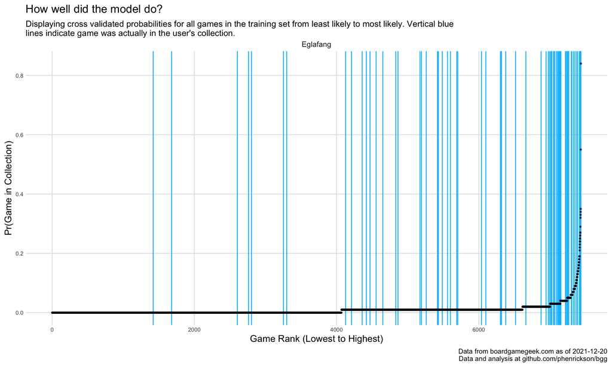

## 3.2 Top Games for **Eglafang** from Training Set

We can display this information in table form, displaying the 100 games with the highest probability of ownership, adding a blue line when the user does own the game.

| username | yearpublished | game_id | name | pred_played | pred_own | actual_played | actual_own |
| --- | --- | --- | --- | --- | --- | --- | --- |
| Eglafang | 2017 | 174430 | Gloomhaven | 0.84 | 0.84 | 0 | 0 |
| Eglafang | 2014 | 163412 | Patchwork | 0.55 | 0.55 | 1 | 1 |
| Eglafang | 2016 | 167791 | Terraforming Mars | 0.35 | 0.35 | 1 | 1 |
| Eglafang | 1997 | 42 | Tigris & Euphrates | 0.34 | 0.34 | 0 | 0 |
| Eglafang | 2018 | 244711 | Newton | 0.33 | 0.33 | 0 | 0 |
| Eglafang | 2019 | 283863 | The Magnificent | 0.32 | 0.32 | 0 | 0 |
| Eglafang | 2005 | 15062 | Shadows over Camelot | 0.29 | 0.29 | 1 | 1 |
| Eglafang | 2014 | 146886 | La Granja | 0.27 | 0.27 | 0 | 0 |
| Eglafang | 2008 | 37141 | Time's Up! Deluxe | 0.27 | 0.27 | 0 | 0 |
| Eglafang | 2014 | 156129 | Deception: Murder in Hong Kong | 0.27 | 0.27 | 0 | 0 |
| Eglafang | 2018 | 258444 | Gingerbread House | 0.26 | 0.26 | 0 | 0 |
| Eglafang | 2016 | 204583 | Kingdomino | 0.26 | 0.26 | 1 | 1 |
| Eglafang | 2019 | 270971 | Era: Medieval Age | 0.25 | 0.25 | 0 | 0 |
| Eglafang | 2018 | 205896 | Rising Sun | 0.25 | 0.25 | 0 | 0 |
| Eglafang | 2015 | 171623 | The Voyages of Marco Polo | 0.24 | 0.24 | 0 | 0 |
| Eglafang | 2012 | 123096 | Space Cadets | 0.24 | 0.24 | 0 | 0 |
| Eglafang | 2004 | 12942 | No Thanks! | 0.23 | 0.23 | 0 | 0 |
| Eglafang | 2017 | 199561 | Sagrada | 0.22 | 0.22 | 0 | 0 |
| Eglafang | 2011 | 70919 | Takenoko | 0.21 | 0.21 | 0 | 0 |
| Eglafang | 2014 | 154203 | Imperial Settlers | 0.19 | 0.19 | 0 | 0 |
| Eglafang | 2019 | 281259 | The Isle of Cats | 0.19 | 0.19 | 1 | 1 |
| Eglafang | 2019 | 276025 | Maracaibo | 0.19 | 0.19 | 0 | 0 |
| Eglafang | 2007 | 33495 | Time's Up! Édition purple | 0.19 | 0.19 | 0 | 0 |
| Eglafang | 2019 | 276498 | Paris: La Cité de la Lumière | 0.18 | 0.18 | 0 | 0 |
| Eglafang | 2019 | 262540 | Freshwater Fly | 0.18 | 0.18 | 0 | 0 |
| Eglafang | 2017 | 231280 | Harvest Dice | 0.17 | 0.17 | 0 | 0 |
| Eglafang | 2017 | 234621 | Tybor the Builder | 0.17 | 0.17 | 0 | 0 |
| Eglafang | 2015 | 175878 | 504 | 0.17 | 0.17 | 0 | 0 |
| Eglafang | 2014 | 166384 | Spyfall | 0.17 | 0.17 | 0 | 0 |
| Eglafang | 2015 | 182874 | Grand Austria Hotel | 0.16 | 0.16 | 0 | 0 |

[output cut: 70 more lines]

We can also more formally assess how well the model did in resampling by looking at the area under the receiver operating characteristic. A perfect model would receive a score of 1, while a model that cannot predict the outcome will default to a score of 0.5. The extent to which something is a *good* score depends on the setting, but generally anything in the .8 to .9 range is very good while the .7 to .8 range is perfectly acceptable.

| username | outcome_type | .metric | .estimator | .estimate |
| --- | --- | --- | --- | --- |
| Eglafang | own | roc_auc | binary | 0.836 |
| Eglafang | played | roc_auc | binary | 0.836 |

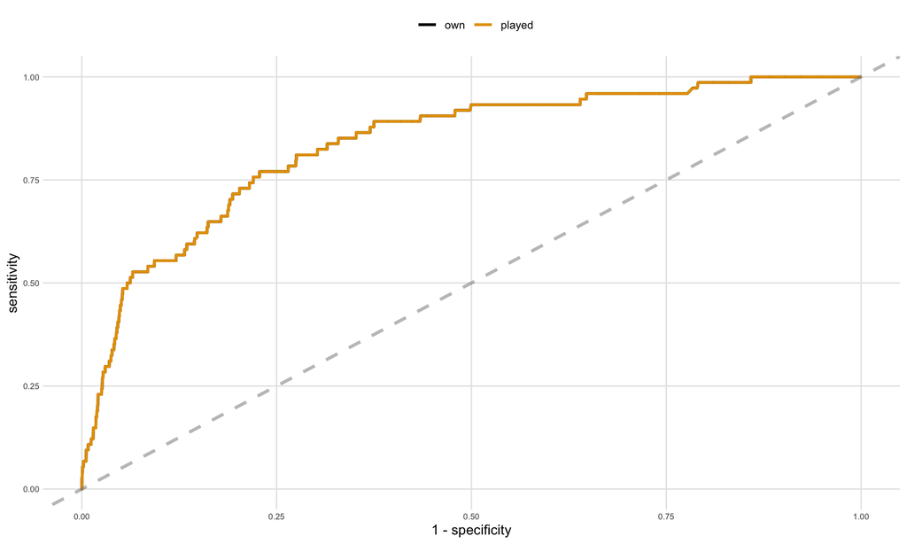

Another way to think about the model performance is to view its lift, or its ability to detect the positive outcomes over that of a null model. High lift indicates the model can much more quickly find all of the positive outcomes (in this case, games owned or played by the user), while a model with no lift is no better than random guessing.

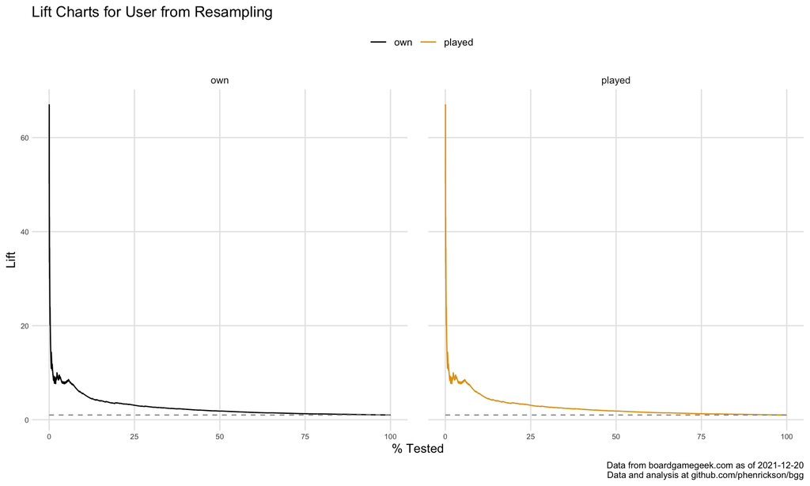

## 3.3 Most and Least Likely Games

What games does the model think Eglafang is **most likely to own** that are **not** in their collection?

| username | yearpublished | game_id | name | pred_own | actual_own |
| --- | --- | --- | --- | --- | --- |
| Eglafang | 2017 | 174430 | Gloomhaven | 0.84 | 0 |
| Eglafang | 1997 | 42 | Tigris & Euphrates | 0.34 | 0 |
| Eglafang | 2018 | 244711 | Newton | 0.33 | 0 |
| Eglafang | 2019 | 283863 | The Magnificent | 0.32 | 0 |
| Eglafang | 2014 | 146886 | La Granja | 0.27 | 0 |

What games does the model think Eglafang is **least likely to own** that **are** in their collection?

| username | yearpublished | game_id | name | pred_own | actual_own |
| --- | --- | --- | --- | --- | --- |
| Eglafang | 2013 | 134626 | Golden Horn: Von Venedig nach Konstantinopel | 0 | 1 |
| Eglafang | 2012 | 124590 | Call to Glory | 0 | 1 |
| Eglafang | 2015 | 180325 | Elfenroads | 0 | 1 |
| Eglafang | 2014 | 153507 | Terra | 0 | 1 |
| Eglafang | 2018 | 256382 | Disney Villainous | 0 | 1 |

## 3.4 Top Games by Year

Top 25 games most likely to be owned by the user in each year, highlighting in blue the games that the user has owned/played.

| rank | 2011 | 2012 | 2013 | 2014 | 2015 | 2016 | 2017 | 2018 | 2019 |
| --- | --- | --- | --- | --- | --- | --- | --- | --- | --- |
| 1 | Takenoko | Space Cadets | Glass Road | Patchwork | The Voyages of Marco Polo | Terraforming Mars | Gloomhaven | Newton | The Magnificent |
| 2 | Streams | Keyflower | Patchistory | La Granja | 504 | Kingdomino | Sagrada | Gingerbread House | Era: Medieval Age |
| 3 | Tragedy Looper | Seasons | Concept | Deception: Murder in Hong Kong | Grand Austria Hotel | The Networks | Harvest Dice | Rising Sun | The Isle of Cats |
| 4 | Ora et Labora | Ginkgopolis | Tajemnicze Domostwo | Imperial Settlers | The Pursuit of Happiness | Codenames: Deep Undercover | Tybor the Builder | Sprawlopolis | Maracaibo |
| 5 | Mundus Novus | Terra Mystica | Bomb Squad | Spyfall | Between Two Cities | La Granja: No Siesta | Bunny Kingdom | Forum Trajanum | Paris: La Cité de la Lumière |
| 6 | Discworld: Ankh-Morpork | Clash of Cultures | The Little Prince: Make Me a Planet | Castles of Mad King Ludwig | Rolling America | The Oregon Trail Card Game | Queendomino | Decrypto | Freshwater Fly |
| 7 | Mage Knight Board Game | Robinson Crusoe: Adventures on the Cursed Island | The Ravens of Thri Sahashri | Witness | Blood Rage | Assembly | The Castles of Burgundy: The Dice Game | The Grizzled: Armistice Edition | Clank!: Legacy – Acquisitions Incorporated |
| 8 | Octopus's Garden | Archipelago | Room 25 | Praetor | New Salem | Agricola (Revised Edition) | Codenames: Duet | Architects of the West Kingdom | Western Empires |
| 9 | Rory's Story Cubes: Voyages | Qin | Funemployed | Five Tribes | My Village | When I Dream | Gaia Project | The City of Kings | Amul |
| 10 | Principato | Star Trek: Catan | Carcassonne: South Seas | Camel Up | The King Is Dead | A Feast for Odin | This War of Mine: The Board Game | Key Flow | Noctiluca |
| 11 | Village | Among the Stars | Sushi Go! | Fields of Arle | Risk: Europe | Covalence: A Molecule Building Game | Magic Maze | Muse: Awakenings | Patchwork Doodle |
| 12 | Mondo | Targi | Asgard's Chosen | Helios | Mysterium | Citadels | Paper Tales | Micropolis | Yōkai |
| 13 | Struggle for Catan | Legends of Andor | Prosperity | Saint Petersburg (Second Edition) | Codenames | Inis | Pulsar 2849 | Everdell | Carnival of Monsters |
| 14 | Catan Histories: Merchants of Europe | Saint Malo | Tash-Kalar: Arena of Legends | Haru Ichiban | Isle of Skye: From Chieftain to King | Mansions of Madness: Second Edition | Muse | Fuji | The Lord of the Rings: Journeys in Middle-Earth |
| 15 | Eclipse | The Manhattan Project | The Builders: Middle Ages | Rolling Japan | The Game | Micro Robots | The Shipwreck Arcana | Scarabya | Yukon Airways |
| 16 | Flash Point: Fire Rescue | Lords of Waterdeep | LEADERS: The Combined Strategy Game | North Wind | T.I.M.E Stories | Islebound | Charterstone | Sherlock: Last Call | Last Bastion |
| 17 | Panic Station | Suburbia | La Boca | Port Royal | The Builders: Antiquity | Beyond Baker Street | Mountains of Madness | Sherlock: 13 Hostages | Hellenica: Story of Greece |
| 18 | Undermining | Mice and Mystics | Spyrium | Gaïa | RYŪ | Sushi Go Party! | Fog of Love | Zombicide: Green Horde | Florenza Dice Game |
| 19 | A Few Acres of Snow | Serenissima (Second Edition) | Bruxelles 1893 | Akrotiri | The Grizzled | Codenames: Pictures | Yamataï | Metro X | Barrage |
| 20 | Martian Dice | Catan: Family Edition | Smash Up: The Obligatory Cthulhu Set | Murano | ...and then, we held hands. | 13 Days: The Cuban Missile Crisis | Valletta | Dice Hospital | Obscurio |
| 21 | The Castles of Burgundy | War of the Ring: Second Edition | Longhorn | Roll Through the Ages: The Iron Age | Haleakala | Pandemic: Reign of Cthulhu | Photosynthesis | Realm of Sand | Old West Empresario |
| 22 | The Gnomes of Zavandor | Africana | Pathfinder Adventure Card Game: Rise of the Runelords – Base Set | Abyss | 7 Wonders Duel | Forged in Steel | Montana | Street Masters | Unlock!: Epic Adventures |
| 23 | Feudalia | Il Vecchio | Legacy: The Testament of Duke de Crecy | Splendor | Raptor | Junk Art | Spirit Island | Cahoots | It's a Wonderful World |
| 24 | Urban Sprawl | The Palaces of Carrara | Romolo o Remo? | Sheep & Thief | Dice City | Braintopia | Clans of Caledonia | Sherlock: Death on the 4th of July | Draftosaurus |
| 25 | Space Empires: 4X | Kairo | Castle Dice | Clinic | Barony | Black Orchestra | Breaking Bad: The Board Game | Werewords Deluxe Edition | The Taverns of Tiefenthal |

## 3.5 Interactive Predictions from Resampling

Interactive table for predictions from resampling.

|  | username | yearpublished | rank | game_id | name | pred_played | pred_own | actual_played | actual_own |
| --- | --- | --- | --- | --- | --- | --- | --- | --- | --- |
| 1 | Eglafang | 1900 | 825 | 11901 | Tic-Tac-Toe | 0.01 | 0.01 | 0 | 0 |
| 2 | Eglafang | 1900 | 856 | 2065 | Shogi | 0.01 | 0.01 | 0 | 0 |
| 3 | Eglafang | 1900 | 920 | 26952 | International Checkers | 0.01 | 0.01 | 0 | 0 |
| 4 | Eglafang | 1900 | 930 | 2083 | Checkers | 0.01 | 0.01 | 0 | 0 |
| 5 | Eglafang | 1900 | 1094 | 7316 | Bingo | 0.01 | 0.01 | 0 | 0 |
| 6 | Eglafang | 1900 | 1702 | 38950 | Halma | 0.01 | 0.01 | 0 | 0 |
| 7 | Eglafang | 1900 | 2170 | 8689 | Bunco | 0.01 | 0.01 | 0 | 0 |
| 8 | Eglafang | 1900 | 2257 | 10815 | Craps | 0.01 | 0.01 | 0 | 0 |
| 9 | Eglafang | 1900 | 2407 | 15878 | Rummy | 0.01 | 0.01 | 0 | 0 |
| 10 | Eglafang | 1900 | 2560 | 45 | Perudo | 0.01 | 0.01 | 0 | 0 |

[output cut: 7426 more lines]

# 4 Validating the Model on 2020

How well did a model trained on a user’s collection through 2019 perform in predicting games for the user from 2020?

| username | outcome_type | yearpublished | .metric | .estimator | .estimate |
| --- | --- | --- | --- | --- | --- |
| Eglafang | own | 2020 | roc_auc | binary | 0.794 |
| Eglafang | played | 2020 | roc_auc | binary | 0.794 |

Table of top 25 games from 2020, highlighting games that the user owns.

| username | yearpublished | game_id | name | pred_own | pred_played | actual_own | actual_played |
| --- | --- | --- | --- | --- | --- | --- | --- |
| Eglafang | 2020 | 184267 | On Mars | 0.78 | 0.78 | 0 | 0 |
| Eglafang | 2020 | 291457 | Gloomhaven: Jaws of the Lion | 0.47 | 0.47 | 0 | 0 |
| Eglafang | 2020 | 316377 | 7 Wonders (Second Edition) | 0.18 | 0.18 | 0 | 0 |
| Eglafang | 2020 | 307844 | Atheneum: Mystic Library | 0.16 | 0.16 | 0 | 0 |
| Eglafang | 2020 | 298271 | Cutterland | 0.15 | 0.15 | 0 | 0 |
| Eglafang | 2020 | 308765 | Praga Caput Regni | 0.14 | 0.14 | 0 | 0 |
| Eglafang | 2020 | 267009 | Rome & Roll | 0.10 | 0.10 | 0 | 0 |
| Eglafang | 2020 | 300322 | Hallertau | 0.10 | 0.10 | 0 | 0 |
| Eglafang | 2020 | 301767 | Mysterium Park | 0.10 | 0.10 | 0 | 0 |
| Eglafang | 2020 | 317231 | Monasterium | 0.10 | 0.10 | 0 | 0 |
| Eglafang | 2020 | 271002 | Myraclia | 0.09 | 0.09 | 0 | 0 |
| Eglafang | 2020 | 281075 | Welcome to New Las Vegas | 0.09 | 0.09 | 1 | 1 |
| Eglafang | 2020 | 320819 | Dinner in Paris | 0.09 | 0.09 | 0 | 0 |
| Eglafang | 2020 | 298017 | Treelings | 0.08 | 0.08 | 0 | 0 |
| Eglafang | 2020 | 315954 | Hunt A Killer: Death at the Dive Bar | 0.08 | 0.08 | 0 | 0 |
| Eglafang | 2020 | 319966 | The King Is Dead: Second Edition | 0.08 | 0.08 | 0 | 0 |
| Eglafang | 2020 | 323784 | Ghost Letters | 0.08 | 0.08 | 0 | 0 |
| Eglafang | 2020 | 262939 | Far Away | 0.07 | 0.07 | 0 | 0 |
| Eglafang | 2020 | 292333 | Cowboys II: Cowboys & Indians Edition | 0.07 | 0.07 | 0 | 0 |
| Eglafang | 2020 | 297030 | Tekhenu: Obelisk of the Sun | 0.07 | 0.07 | 0 | 0 |
| Eglafang | 2020 | 302465 | Obsidia | 0.07 | 0.07 | 0 | 0 |
| Eglafang | 2020 | 303672 | Trek 12: Himalaya | 0.07 | 0.07 | 0 | 0 |
| Eglafang | 2020 | 313008 | Apollo: A Game Inspired by NASA Moon Missions | 0.07 | 0.07 | 0 | 0 |
| Eglafang | 2020 | 316622 | Gods Love Dinosaurs | 0.07 | 0.07 | 0 | 0 |
| Eglafang | 2020 | 325555 | Cantaloop: Book 1 – Breaking into Prison | 0.07 | 0.07 | 0 | 0 |

# 5 Predicting Upcoming Games (2020 and On) for **Eglafang**

Examine the top games for the test set.

| username | yearpublished | game_id | name | rank | own | played |
| --- | --- | --- | --- | --- | --- | --- |
| Eglafang | 2020 | 184267 | On Mars | 1 | 0.78 | 0.78 |
| Eglafang | 2020 | 291457 | Gloomhaven: Jaws of the Lion | 2 | 0.47 | 0.47 |
| Eglafang | 2020 | 316377 | 7 Wonders (Second Edition) | 3 | 0.18 | 0.18 |
| Eglafang | 2020 | 307844 | Atheneum: Mystic Library | 4 | 0.16 | 0.16 |
| Eglafang | 2020 | 298271 | Cutterland | 5 | 0.15 | 0.15 |
| Eglafang | 2020 | 308765 | Praga Caput Regni | 6 | 0.14 | 0.14 |
| Eglafang | 2020 | 317231 | Monasterium | 7 | 0.10 | 0.10 |
| Eglafang | 2020 | 267009 | Rome & Roll | 8 | 0.10 | 0.10 |
| Eglafang | 2020 | 300322 | Hallertau | 9 | 0.10 | 0.10 |
| Eglafang | 2020 | 301767 | Mysterium Park | 10 | 0.10 | 0.10 |
| Eglafang | 2020 | 320819 | Dinner in Paris | 11 | 0.09 | 0.09 |
| Eglafang | 2020 | 271002 | Myraclia | 12 | 0.09 | 0.09 |
| Eglafang | 2020 | 281075 | Welcome to New Las Vegas | 13 | 0.09 | 0.09 |
| Eglafang | 2020 | 319966 | The King Is Dead: Second Edition | 14 | 0.08 | 0.08 |
| Eglafang | 2020 | 298017 | Treelings | 15 | 0.08 | 0.08 |
| Eglafang | 2020 | 315954 | Hunt A Killer: Death at the Dive Bar | 16 | 0.08 | 0.08 |
| Eglafang | 2020 | 323784 | Ghost Letters | 17 | 0.08 | 0.08 |
| Eglafang | 2020 | 292333 | Cowboys II: Cowboys & Indians Edition | 18 | 0.07 | 0.07 |
| Eglafang | 2020 | 325555 | Cantaloop: Book 1 – Breaking into Prison | 19 | 0.07 | 0.07 |
| Eglafang | 2020 | 303672 | Trek 12: Himalaya | 20 | 0.07 | 0.07 |
| Eglafang | 2020 | 316622 | Gods Love Dinosaurs | 21 | 0.07 | 0.07 |
| Eglafang | 2020 | 297030 | Tekhenu: Obelisk of the Sun | 22 | 0.07 | 0.07 |
| Eglafang | 2020 | 302465 | Obsidia | 23 | 0.07 | 0.07 |
| Eglafang | 2020 | 313008 | Apollo: A Game Inspired by NASA Moon Missions | 24 | 0.07 | 0.07 |
| Eglafang | 2020 | 262939 | Far Away | 25 | 0.07 | 0.07 |
| Eglafang | 2021 | 298102 | Roll Camera!: The Filmmaking Board Game | 1 | 0.40 | 0.40 |
| Eglafang | 2021 | 340041 | Kingdomino Origins | 2 | 0.29 | 0.29 |
| Eglafang | 2021 | 343905 | Boonlake | 3 | 0.26 | 0.26 |
| Eglafang | 2021 | 319999 | Dungeon Decorators | 4 | 0.19 | 0.19 |
| Eglafang | 2021 | 282776 | Tumble Town | 5 | 0.18 | 0.18 |
| Eglafang | 2021 | 314088 | Agropolis | 6 | 0.15 | 0.15 |
| Eglafang | 2021 | 313269 | Rescuing Robin Hood | 7 | 0.13 | 0.13 |
| Eglafang | 2021 | 249277 | Brazil: Imperial | 8 | 0.12 | 0.12 |
| Eglafang | 2021 | 295947 | Cascadia | 9 | 0.12 | 0.12 |
| Eglafang | 2021 | 301441 | Drawn to Adventure | 10 | 0.11 | 0.11 |
| Eglafang | 2021 | 293665 | Ensemble | 11 | 0.11 | 0.11 |
| Eglafang | 2021 | 323118 | Crack the Code | 12 | 0.10 | 0.10 |
| Eglafang | 2021 | 252752 | Genotype: A Mendelian Genetics Game | 13 | 0.10 | 0.10 |
| Eglafang | 2021 | 310873 | Carnegie | 14 | 0.09 | 0.09 |
| Eglafang | 2021 | 344415 | Trek 12: Amazonia | 15 | 0.08 | 0.08 |
| Eglafang | 2021 | 291859 | Riftforce | 16 | 0.08 | 0.08 |
| Eglafang | 2021 | 337765 | Brian Boru: High King of Ireland | 17 | 0.08 | 0.08 |
| Eglafang | 2021 | 291847 | Mantis Falls | 18 | 0.08 | 0.08 |
| Eglafang | 2021 | 316786 | Tabannusi: Builders of Ur | 19 | 0.07 | 0.07 |
| Eglafang | 2021 | 295535 | Dark Ages: Heritage of Charlemagne | 20 | 0.07 | 0.07 |
| Eglafang | 2021 | 304985 | Dark Ages: Holy Roman Empire | 21 | 0.07 | 0.07 |
| Eglafang | 2021 | 342942 | Ark Nova | 22 | 0.07 | 0.07 |
| Eglafang | 2021 | 324856 | The Crew: Mission Deep Sea | 23 | 0.07 | 0.07 |
| Eglafang | 2021 | 286632 | Blood of the Northmen | 24 | 0.06 | 0.06 |
| Eglafang | 2021 | 315767 | Cartographers Heroes | 25 | 0.06 | 0.06 |
| Eglafang | 2022 | 334065 | Verdant | 1 | 0.29 | 0.29 |
| Eglafang | 2022 | 295770 | Frosthaven | 2 | 0.25 | 0.25 |
| Eglafang | 2022 | 258779 | Planet Unknown | 3 | 0.09 | 0.09 |
| Eglafang | 2022 | 317511 | Tindaya | 4 | 0.07 | 0.07 |
| Eglafang | 2022 | 331106 | The Witcher: Old World | 5 | 0.05 | 0.05 |
| Eglafang | 2022 | 311988 | Frostpunk: The Board Game | 6 | 0.04 | 0.04 |
| Eglafang | 2022 | 326945 | Castles of Mad King Ludwig: Collector's Edition | 7 | 0.03 | 0.03 |
| Eglafang | 2022 | 336986 | Flamecraft | 8 | 0.03 | 0.03 |
| Eglafang | 2022 | 319807 | Shogun no Katana | 9 | 0.03 | 0.03 |
| Eglafang | 2022 | 283137 | Human Punishment: The Beginning | 10 | 0.03 | 0.03 |
| Eglafang | 2022 | 338067 | 6: Siege – The Board Game | 11 | 0.03 | 0.03 |
| Eglafang | 2022 | 273814 | Deliverance | 12 | 0.03 | 0.03 |
| Eglafang | 2022 | 317321 | Darkest Dungeon: The Board Game | 13 | 0.03 | 0.03 |
| Eglafang | 2022 | 256680 | Return to Dark Tower | 14 | 0.03 | 0.03 |
| Eglafang | 2022 | 284189 | Foundations of Rome | 15 | 0.03 | 0.03 |
| Eglafang | 2022 | 281647 | Stellaris: Infinite Legacy | 16 | 0.02 | 0.02 |
| Eglafang | 2022 | 271601 | Feed the Kraken | 17 | 0.02 | 0.02 |
| Eglafang | 2022 | 284118 | Mechanical Beast | 18 | 0.02 | 0.02 |
| Eglafang | 2022 | 240980 | Blood on the Clocktower | 19 | 0.02 | 0.02 |
| Eglafang | 2022 | 330950 | Age of Galaxy | 20 | 0.02 | 0.02 |
| Eglafang | 2022 | 340325 | Vagrantsong | 21 | 0.02 | 0.02 |
| Eglafang | 2022 | 274124 | Northgard: Uncharted Lands | 22 | 0.02 | 0.02 |
| Eglafang | 2022 | 276182 | Dead Reckoning | 23 | 0.02 | 0.02 |
| Eglafang | 2022 | 304051 | Creature Comforts | 24 | 0.02 | 0.02 |
| Eglafang | 2022 | 322524 | Bardsung | 25 | 0.02 | 0.02 |

## 5.1 Interactive Table for Upcoming Games 2020 and On

|  | username | yearpublished | game_id | name | rank | own | played |
| --- | --- | --- | --- | --- | --- | --- | --- |
| 1 | Eglafang | 2020 | 184267 | On Mars | 1 | 0.78 | 0.78 |
| 2 | Eglafang | 2020 | 291457 | Gloomhaven: Jaws of the Lion | 2 | 0.47 | 0.47 |
| 3 | Eglafang | 2021 | 298102 | Roll Camera!: The Filmmaking Board Game | 3 | 0.4 | 0.4 |
| 4 | Eglafang | 2021 | 340041 | Kingdomino Origins | 4 | 0.29 | 0.29 |
| 5 | Eglafang | 2022 | 334065 | Verdant | 5 | 0.29 | 0.29 |
| 6 | Eglafang | 2021 | 343905 | Boonlake | 6 | 0.26 | 0.26 |
| 7 | Eglafang | 2022 | 295770 | Frosthaven | 7 | 0.25 | 0.25 |
| 8 | Eglafang | 2021 | 319999 | Dungeon Decorators | 8 | 0.19 | 0.19 |
| 9 | Eglafang | 2021 | 282776 | Tumble Town | 9 | 0.18 | 0.18 |
| 10 | Eglafang | 2020 | 316377 | 7 Wonders (Second Edition) | 10 | 0.18 | 0.18 |

[output cut: 1627 more lines]